# Evaluation: 16 El Conejo

**WB Group, LLC** Property Management Contact: Francis Rojas, 512-422-0210

## Ranger Properties

- asking $277K
- Buy Contract
- Deed 2018 : $216,997

Here are the stats:

## Discussed

- This is a sale of 'contract' (1031 Exchange?)
- Parties: Seller, RE agent, Rangers, Buyer --- title co

## Parties

1. The Property Rangers: Devin Hallier, 512-865-6356, devinbuysaustin25@gmail.com
   - Instagram: @propertyrangerllc
   - https://thepropertyrangers.com
2. Independence title: Nora Williams
3. RE agent
4. Seller - CLECKLER REBEKAH RANKIN
5. Buyer

## STATE OF PROP / FIXUP

Inspection TBD:

- HVAC: Unit A: may need new HVAC Unit B: has new HVAC (June)
- Foundation: recently added piers where needed(working on more info)
- Plumbing: Currently on Septic serviced jan 5th 2026-needs to be changed to city sewer per owner-septic needs replacement per owner.

## Questions:

- Do I get to see the 1031 Exchange agreement?
- Next step: what is needed? Timeline? Downpayments?
- What are the steps to closing? Ie. standard RE events or ??
- Seller disclosure available?
- Will the seller be wanting to rent? Lease?
- Can I get a copy of the current Lease?
- Any HOA?

## Market/Econommy

The central question is whether the market/economy will move this house and time it will be on market.

The 2026 real estate outlook suggests

- a stabilizing market with slow,
- modest home price growth,
- improved affordability due to easing mortgage rates, and
- better inventory levels in some regions
- though overall supply remains tight; expect continued regional differences,
- with strong commercial sectors like multifamily and industrial,
- while residential markets see slow normalization.

## Residential Market (2026)

- **Price Growth**: Forecasts predict slow national price increases (around 1-2%), with real (inflation-adjusted) prices potentially declining, making homes more affordable relative to income.
- **Mortgage Rates**: Rates are expected to decrease, helping offset price gains and improving monthly affordability.
- **Inventory**: Supply is gradually improving but remains below pre-pandemic levels, especially in the Northeast and Midwest.
- **Sales**: Existing home sales are predicted to rise as affordability improves and more homeowners list properties.
- **Regional Differences**: Markets in the South and West are more balanced due to increased construction, while the Northeast and Midwest still lag in inventory.

## Pricing sensitivity and balance:

[How to keep sellers committed](https://www.nar.realtor/magazine/real-estate-news/sales-and-marketing/prevent-home-delistings-how-agents-can-keep-sellers-committed]

- “In recent data, we’ve noticed that the share of sellers pulling their homes off the market is higher than normal.
- Even then, it’s still only about 6% of listings, so it’s definitely not the norm.
- What it reflects is a more balanced housing market where not every seller is getting exactly what they want.
- Some are choosing to come down in price, and
- others are choosing to walk away and come back at a later date because they have the flexibility to wait.
- “Using NAR month-supply data, **the housing market is the most balanced it’s been in almost a decade**.
- Buyers have a little more leeway; sellers have to be more flexible, and
- that’s a big shift from the pandemic years when sellers had nearly all the leverage.”

## Stats

```python
# Inputs

askPrice = 277000
mktValue = 288000 # Hays Co

purYr = 2018
purPrice = 216997
selGain = askPrice-purPrice

## Zillow
zilPrice = 211000
zilPct = 1.20 # 20% mark up
zilPriceMkup = zilPrice*pctZil

## Realtor
rePrice = 200000
rePct = 1.10
rePriceMkup = rePrice * rePct

yr = int(datetime.datetime.now().strftime('%Y'))

# Compute future value using Formula: FV = PV * (1 + r)^n
principal = purPrice  # Initial investment
reRate = 0.04
years = yr-purYr          # Investment duration

def fvCalc(PV, R, yrs):
    return PV * ((2 + R) ** yrs)
#fv = principal * ((1 + reRate) ** years)
fv = fvCalc(principal, reRate, years)


print("Years;", yr-purYr)
print(f"Seller Gain (2018-26): ${askPrice-purPrice:,}   PerYear:{int(selGain/(yr-purYr))}")
print(f"RE Std  FV: ${fv:,.0f}") # Output: Manual FV: $14,025.52
print("--------------")
print(f"Pct.Ask::Std     :  {100*askPrice/fv:.1f}%", int(fv), int(askPrice))
print(f"Pct.Ask::PropTax :  {100*askPrice/mktValue:.1f}%", int(mktValue), int(askPrice))
print()
print(f"Pct.Ask::Zil+.   : {100*askPrice/zilPriceMkup:.1f}%", int(zilPriceMkup), int(askPrice), f"Gain: {int(askPrice-zilPriceMkup):,}")
print(f"Pct.Ask::Zil     : {100*askPrice/zilPrice:.1f}%", int(zilPrice), int(askPrice), f"Gain: {askPrice-zilPrice:,}")
print()
print(f"Pct.Ask::Realtor+: {100*askPrice/rePriceMkup:.1f}%", int(rePriceMkup), int(askPrice), f"Gain: {int(askPrice-rePriceMkup):,}")
print(f"Pct.Ask::Realto  : {100*askPrice/rePrice:.1f}%", int(rePrice), int(askPrice), f"Gain: {askPrice-rePrice:,}")
```

```
Years; 8
Seller Gain (2018-26): $60,003   PerYear:7500
RE Std  FV: $65,087,122
--------------
Pct.Ask::Std     :  0.4% 65087122 277000
Pct.Ask::PropTax :  96.2% 288000 277000

Pct.Ask::Zil+.   : 109.4% 253200 277000 Gain: 23,800
Pct.Ask::Zil     : 131.3% 211000 277000 Gain: 66,000

Pct.Ask::Realtor+: 125.9% 220000 277000 Gain: 56,999
Pct.Ask::Realto  : 138.5% 200000 277000 Gain: 77,000
```

## History: Prop Mkt Value and Percent of Land

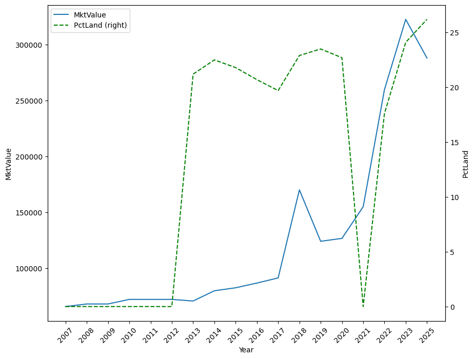

```python
# Prop History - Realtor.com

csvStr = '''Year	Taxes	MktValue	equals	Land	add	Additions
2025	$4,473	$288,080	=	$75,520	+	$212,560
2023	$4,526	$322,620	=	$77,880	+	$244,740
2022	$4,130	$259,800	=	$45,600	+	$214,200
2021	$2,623	$155,152	=	-	+	-
2020	$2,256	$126,880	=	$28,800	+	$98,080
2019	$2,290	$124,290	=	$29,250	+	$95,040
2018	$3,230	$170,230	=	$39,000	+	$131,230
2017	$1,685	$91,550	=	$18,000	+	$73,550
2016	$1,613	$86,960	=	$18,000	+	$68,960
2015	$1,542	$82,750	=	$18,000	+	$64,750
2014	$1,494	$80,070	=	$18,000	+	$62,070
2013	$1,324	$70,910	=	$15,000	+	$55,910
2012	$1,319	$72,360	=	-	+	-
2011	$1,305	$72,360	=	-	+	-
2010	$1,300	$72,360	=	-	+	-
2009	$1,224	$68,270	=	-	+	-
2008	$1,215	$68,270	=	-	+	-
2007	$1,160	$65,970	=	-	+	-'''.replace('$','').replace(',','')
import pandas as pd
from io import StringIO
with StringIO(('\n'.join([','.join(ln.split()) for ln in csvStr.split('\n')]))) as sio:
    df = pd.read_csv(sio)
cols = ['Year', 'Taxes', 'MktValue', 'Land','Additions', 'PctLand']
df['PctLand'] = df.apply(lambda r: round(100*int(r.Land)/int(r.MktValue) if r.Land != '-' else 0,1), axis=1)
df[cols]

df.sort_values(by='Year', ascending=True, inplace=True)
df.reset_index(drop=True, inplace=True)

# Plotting with a secondary y-axis
ax = df.sort_values(by='Year', ascending=True).plot(y='MktValue', legend=True, figsize=(10,8))
ax2 = df.sort_values(by='Year', ascending=True).plot(y='PctLand', secondary_y=True, ax=ax, legend=True, color='g', style='--')

# Set labels for the y-axes
ax.set_ylabel('MktValue')
ax2.set_ylabel('PctLand')
ax.set_xlabel('Year')

# Set custom tick locations and labels using matplotlib
ax.set_xticks(range(len(df)))
_ = ax.set_xticklabels(df.Year, rotation=45) # Optional: rotate labels for readability
```

```python
df.sort_values(by='Year', ascending=True, inplace=True)
df.reset_index(drop=True)
```

|  | Year | Taxes | MktValue | equals | Land | add | Additions | PctLand |
| --- | --- | --- | --- | --- | --- | --- | --- | --- |
| 0 | 2007 | 1160 | 65970 | = | - | + | - | 0.0 |
| 1 | 2008 | 1215 | 68270 | = | - | + | - | 0.0 |
| 2 | 2009 | 1224 | 68270 | = | - | + | - | 0.0 |
| 3 | 2010 | 1300 | 72360 | = | - | + | - | 0.0 |
| 4 | 2011 | 1305 | 72360 | = | - | + | - | 0.0 |
| 5 | 2012 | 1319 | 72360 | = | - | + | - | 0.0 |
| 6 | 2013 | 1324 | 70910 | = | 15000 | + | 55910 | 21.2 |
| 7 | 2014 | 1494 | 80070 | = | 18000 | + | 62070 | 22.5 |
| 8 | 2015 | 1542 | 82750 | = | 18000 | + | 64750 | 21.8 |
| 9 | 2016 | 1613 | 86960 | = | 18000 | + | 68960 | 20.7 |
| 10 | 2017 | 1685 | 91550 | = | 18000 | + | 73550 | 19.7 |
| 11 | 2018 | 3230 | 170230 | = | 39000 | + | 131230 | 22.9 |
| 12 | 2019 | 2290 | 124290 | = | 29250 | + | 95040 | 23.5 |
| 13 | 2020 | 2256 | 126880 | = | 28800 | + | 98080 | 22.7 |
| 14 | 2021 | 2623 | 155152 | = | - | + | - | 0.0 |
| 15 | 2022 | 4130 | 259800 | = | 45600 | + | 214200 | 17.6 |
| 16 | 2023 | 4526 | 322620 | = | 77880 | + | 244740 | 24.1 |
| 17 | 2025 | 4473 | 288080 | = | 75520 | + | 212560 | 26.2 |

## 10 year ROI : RE vs MKT

```python
# Compute ROI
fixup = 10000
salePrice = (askPrice * 0.90) - fixup

mktRate = 0.08
roiYears = 10

reRateExp = 0.20 # Rental PropTax/Maintainance Expense


def apprValue(PV, R, years):
    p = PV
    for i in range(years):
        p = p * (1.0 + R)

    return int(p)

def fvDF(salePrice, nm, **kwargs):

    rent = kwargs.get('rent', 2600)

    mktFV = apprValue(salePrice, mktRate, roiYears)
    reInc = int(rent*12*roiYears*0.8)
    reFVProp = apprValue(salePrice, reRate, roiYears)
    reFV = reFVProp + reInc
    return pd.DataFrame([dict(SalePrice = int(salePrice),
                        FV_mkt_8Pct = mktFV,
                        FV_RE = reFV,
                        FV_mkt_10Pct = apprValue(salePrice, 0.1, roiYears),
                        FV_RE_Prop = reFVProp,
                        FV_RE_Income = reInc,
                        PerYr_mkt = int(mktFV/roiYears),
                        PerYr_RE = int(reFV/roiYears)
                       )], index=[nm])
roiDF = pd.concat([fvDF(240000,'sale240K'),
           fvDF(265000, 'Sale265K'),
           fvDF(277000, 'Sale277K')
          ]).transpose()
roiDF
```

|  | sale240K | Sale265K | Sale277K |
| --- | --- | --- | --- |
| SalePrice | 240000 | 265000 | 277000 |
| FV_mkt_8Pct | 518141 | 572115 | 598022 |
| FV_RE | 604858 | 641864 | 659627 |
| FV_mkt_10Pct | 622498 | 687341 | 718466 |
| FV_RE_Prop | 355258 | 392264 | 410027 |
| FV_RE_Income | 249600 | 249600 | 249600 |
| PerYr_mkt | 51814 | 57211 | 59802 |
| PerYr_RE | 60485 | 64186 | 65962 |

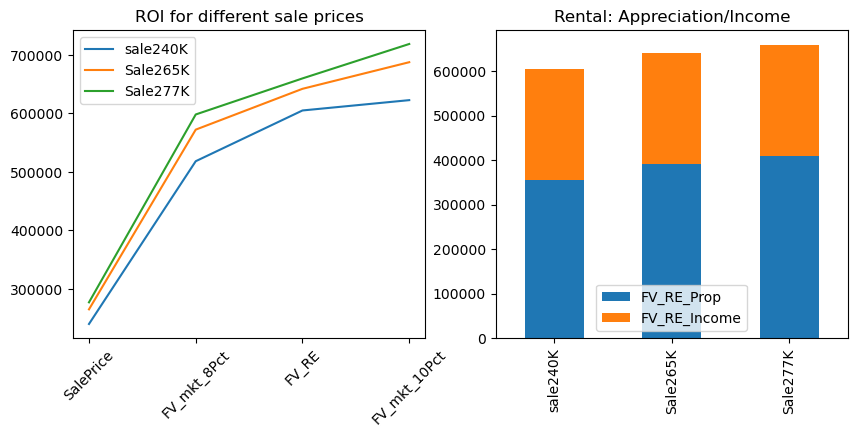

```python
import matplotlib.pyplot as plt

vDF = roiDF.iloc[:-4]

xList = list(vDF.index)
xLen = len(xList)

fig, (ax1, ax2) = plt.subplots(nrows=1, ncols=2, figsize=(10, 4)) #


vDF.plot(ax=ax1, title='ROI for different sale prices')

ax1.set_xticks(range(xLen))
_ = ax1.set_xticklabels(xList, rotation=45) # Optional: rotate labels for readability

roiDF.iloc[4:6].transpose().plot(ax=ax2, kind='bar', stacked='True', title='Rental: Appreciation/Income')
```